# Exercise 12.10

Kári Hlynsson

April 2024

In this problem, you will generate simulated data, and then perform PCA and $K$-means clustering on the data.

## Part (a)

Generate a simulated data set with 20 observations in each of three classes (i.e. 60 observations total), and 50 variables.

```r
set.seed(1)

n <- 60
p <- 50
k <- 3

x <- matrix(rnorm(n * p), ncol = p)
colnames(x) <- paste0("X", 1:p)

ks <- sample(1:k, n, replace = TRUE)

x[ks == 1, 1:10] <- x[ks == 1, 1:10] - 1.53
x[ks == 2, 7:29] <- x[ks == 2, 7:29] + 0.98
```

## Part (b)

Perform PCA on the 60 observations and plot the first two principal component score vectors. Use a different colour to indicate the observations in each of the three classes. If the three classes appear separated in this plot, then continue on to part (c). If not, then return to part (a) and modify the simulation so that there is greater separation between the three classes. Do not continue to part (c) until the three classes show at least some separation in the first two principal component score vectors.

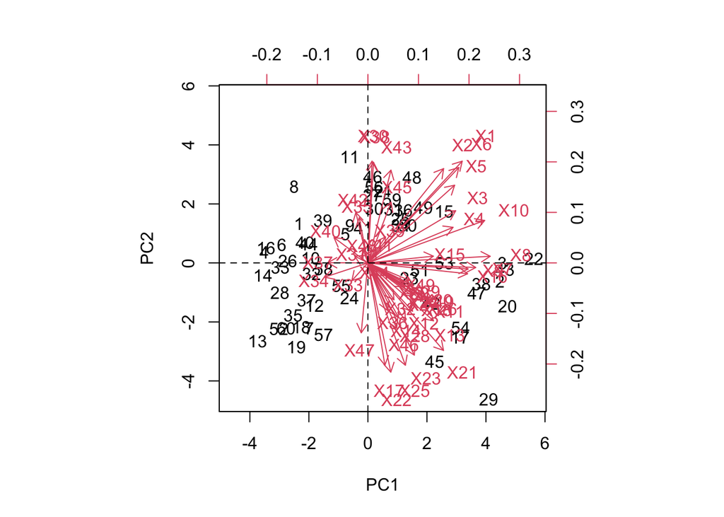

```r
pr_out <- prcomp(x, scale = TRUE)
biplot(pr_out, scale = 0)
abline(h = 0, lty = 2)
abline(v = 0, lty = 2)
```

Scatterplot with class labels:

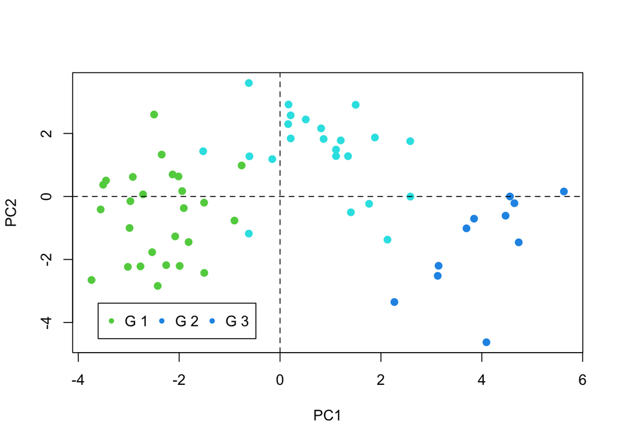

```r
plot(pr_out$x[, 1], pr_out$x[, 2], col = ks + 2, pch = 20, cex = 1.55,
     xlab = "PC1", ylab = "PC2")
legend("bottomleft", inset = c(0.05, 0.05), pch = 20, col = ks + 2,
       legend = paste("G", 1:3), horiz = TRUE, xpd = TRUE)
abline(h = 0, lty = 2)
abline(v = 0, lty = 2)
```

## Part (c)

Perform $K$-means clustering of the observations with $K = 3$. How well do the clusters that you obtained in $K$-means clustering compare to the true class labels?

```r
km_out <- kmeans(x, 3, nstart = 20)

tab_km <- table(km_out$cluster, ks)
tab_km
```

```
##    ks
##      1  2  3
##   1  0 11  1
##   2  0  0 21
##   3 26  0  1
```

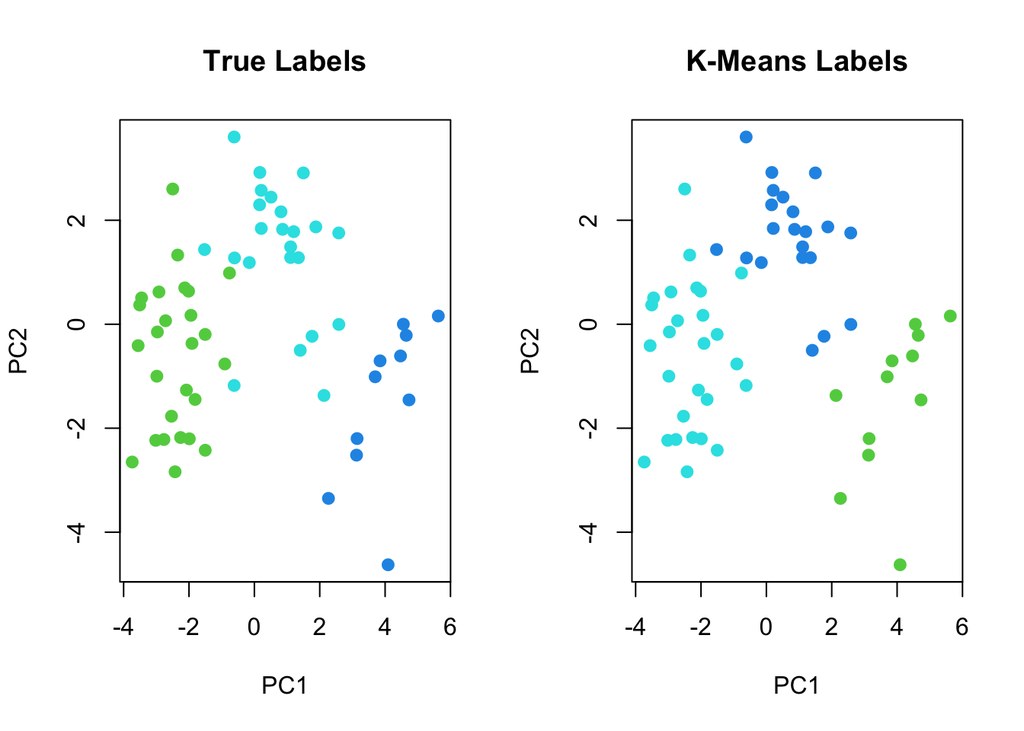

```r
par(mfrow = c(1, 2))

plot(pr_out$x[, 1], pr_out$x[, 2], col = ks + 2, pch = 20, cex = 1.55,
     xlab = "PC1", ylab = "PC2", main = "True Labels")

plot(pr_out$x[, 1], pr_out$x[, 2], col = km_out$cluster + 2, pch = 20,
     cex = 1.55, xlab = "PC1", ylab = "PC2", main = "K-Means Labels")
```

## Part (d)

Perform $K$-means clustering with $K = 2$. Describe the results.

```r
km_out <- kmeans(x, 2, nstart = 20)

tab_km <- table(km_out$cluster, ks)
tab_km
```

```
##    ks
##      1  2  3
##   1  0 11 21
##   2 26  0  2
```

The algorithm pairs together the two closer cluster into a new cluster.

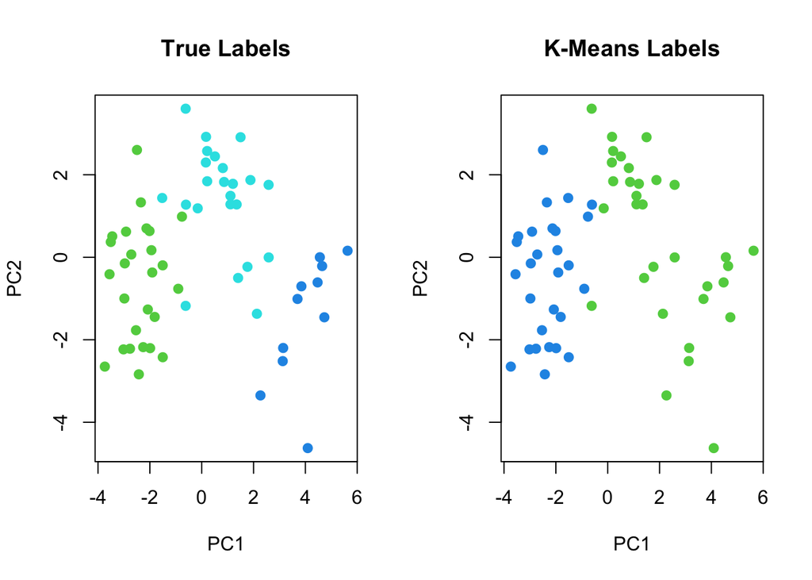

```r
par(mfrow = c(1, 2))

plot(pr_out$x[, 1], pr_out$x[, 2], col = ks + 2, pch = 20, cex = 1.55,
     xlab = "PC1", ylab = "PC2", main = "True Labels")

plot(pr_out$x[, 1], pr_out$x[, 2], col = km_out$cluster + 2, pch = 20,
     cex = 1.55, xlab = "PC1", ylab = "PC2", main = "K-Means Labels")
```

# Part (e)

Now perform $K$-means clustering with $K = 4$, and describe your results.

```r
km_out <- kmeans(x, 4, nstart = 20)

tab_km <- table(km_out$cluster, ks)
tab_km
```

```
##    ks
##      1  2  3
##   1  8  0  2
##   2  0 11  3
##   3 18  0  0
##   4  0  0 18
```

The algorithm splits up two of the true clusters (green and teal in the visualisation) to accomodate the new cluster.

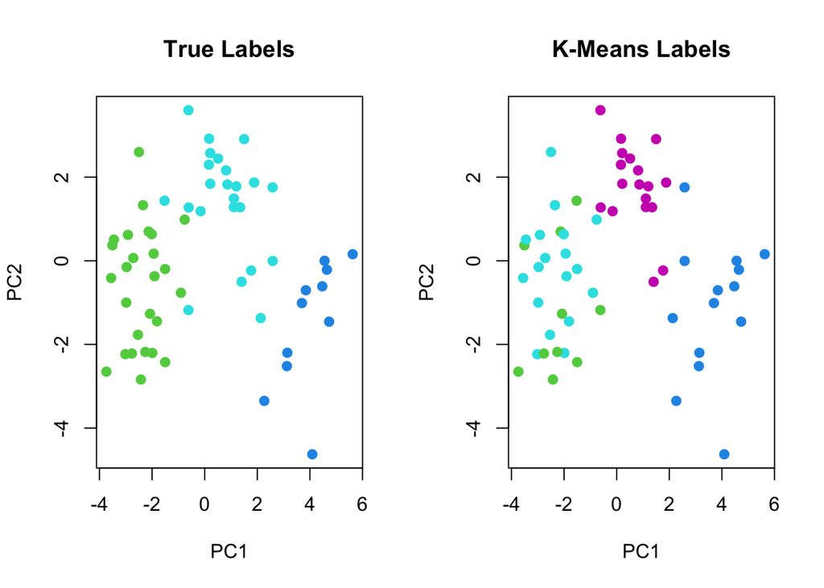

```r
par(mfrow = c(1, 2))

plot(pr_out$x[, 1], pr_out$x[, 2], col = ks + 2, pch = 20, cex = 1.55,
     xlab = "PC1", ylab = "PC2", main = "True Labels")

plot(pr_out$x[, 1], pr_out$x[, 2], col = km_out$cluster + 2, pch = 20,
     cex = 1.55, xlab = "PC1", ylab = "PC2", main = "K-Means Labels")
```

## Part (f)

Now perform $K$-means clustering with $K = 3$ on the first two principal component score vectors, rather than on the raw data. That is, perform $K$-means clustering on the $60 \times 2$ matrix of which the first column is the first principal component score vector, and the second column is the second principal component score vector. Comment on the results.

```r
km_out <- kmeans(pr_out$x[, 1:2], 3, nstart = 20)

tab_km <- table(km_out$cluster, ks)
tab_km
```

```
##    ks
##      1  2  3
##   1  2  0 18
##   2  0 11  4
##   3 24  0  1
```

Good performance, but not quite as good as when we ran K-means on the raw data with $K = 3$. Visual:

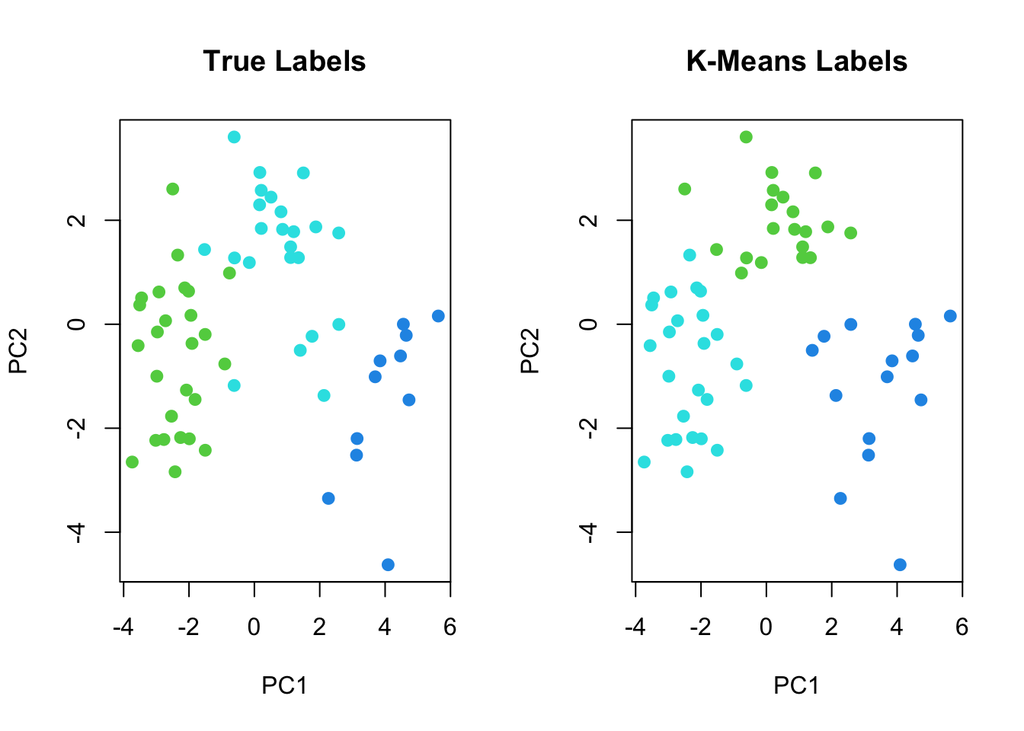

```r
par(mfrow = c(1, 2))

plot(pr_out$x[, 1], pr_out$x[, 2], col = ks + 2, pch = 20, cex = 1.55,
     xlab = "PC1", ylab = "PC2", main = "True Labels")

plot(pr_out$x[, 1], pr_out$x[, 2], col = km_out$cluster + 2, pch = 20,
     cex = 1.55, xlab = "PC1", ylab = "PC2", main = "K-Means Labels")
```

## Part (g)

Using the `scale()` function, perform $K$-means clustering with $K = 3$ on the data *after scaling each variable to have standard deviation one*. How do these results compare to those obtained in (b)? Explain.

```r
km_out <- kmeans(scale(x), 3, nstart = 20)

tab_km <- table(km_out$cluster, ks)
tab_km
```

```
##    ks
##      1  2  3
##   1 26  0  1
##   2  0 11  2
##   3  0  0 20
```

Great performance, not as good as on the raw data though.

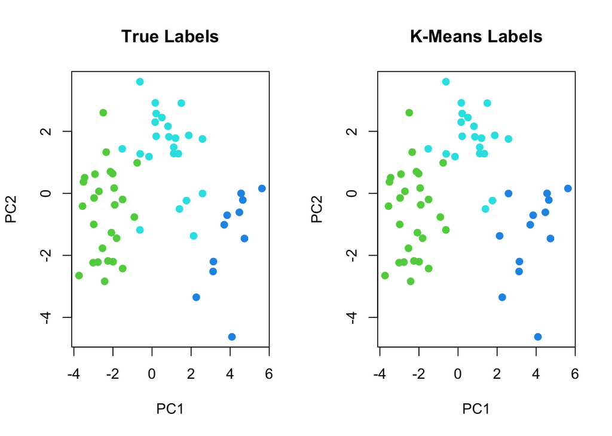

```r
par(mfrow = c(1, 2))

plot(pr_out$x[, 1], pr_out$x[, 2], col = ks + 2, pch = 20, cex = 1.55,
     xlab = "PC1", ylab = "PC2", main = "True Labels")

plot(pr_out$x[, 1], pr_out$x[, 2], col = km_out$cluster + 2, pch = 20,
     cex = 1.55, xlab = "PC1", ylab = "PC2", main = "K-Means Labels")
```